# Project 2 _Data Analysis

### Investigating Titanic Dataset

In this document I will include some analysis for the titanc data file using Pandas. the file contains some information of 891 passengers and crew on board of the titanic.

By analysing the data, I will try to find answers for the following questions:

- what was the survival rate in the given dataset?
- what are the characterstics of the survived?
- was passengers of class 1 are more likley to survive?

```python
# opening the file & Loading Data
import pandas as pd
import numpy as np
import matplotlib.pyplot as plt
from IPython.display import display
%matplotlib inline

df= pd.read_csv('titanic.csv')

df.head()
```

|  | PassengerId | Survived | Pclass | Name | Sex | Age | SibSp | Parch | Ticket | Fare | Cabin | Embarked |
| --- | --- | --- | --- | --- | --- | --- | --- | --- | --- | --- | --- | --- |
| 0 | 1 | 0 | 3 | Braund, Mr. Owen Harris | male | 22.0 | 1 | 0 | A/5 21171 | 7.2500 | NaN | S |
| 1 | 2 | 1 | 1 | Cumings, Mrs. John Bradley (Florence Briggs Th... | female | 38.0 | 1 | 0 | PC 17599 | 71.2833 | C85 | C |
| 2 | 3 | 1 | 3 | Heikkinen, Miss. Laina | female | 26.0 | 0 | 0 | STON/O2. 3101282 | 7.9250 | NaN | S |
| 3 | 4 | 1 | 1 | Futrelle, Mrs. Jacques Heath (Lily May Peel) | female | 35.0 | 1 | 0 | 113803 | 53.1000 | C123 | S |
| 4 | 5 | 0 | 3 | Allen, Mr. William Henry | male | 35.0 | 0 | 0 | 373450 | 8.0500 | NaN | S |

```python
# An overview analysis on the data types, number of rows and columns

# number of rows and columns (Row, Col)
df.shape
```

```
(891, 12)
```

```python
#  data types:

df.dtypes
```

```
PassengerId      int64
Survived         int64
Pclass           int64
Name            object
Sex             object
Age            float64
SibSp            int64
Parch            int64
Ticket          object
Fare           float64
Cabin           object
Embarked        object
dtype: object
```

```python
#looking for columns with no values and filling it with appropriate values

df.isnull().sum()
```

```
PassengerId      0
Survived         0
Pclass           0
Name             0
Sex              0
Age            177
SibSp            0
Parch            0
Ticket           0
Fare             0
Cabin          687
Embarked         2
dtype: int64
```

The dataset has 177 missing value for passengers age , 687 missing cabin data and Embarked data for 2 passengers are not recorded.

```python
#Calculating average Age for male and female

FemaleAgeAvg= df['Age'].where(df['Sex']=='female').mean()

MaleAgeAvg= df['Age'].where(df['Sex']=='male').mean()
```

```python
# Filling the missing Age data with average value for each gender

df['Age'].where(df['Sex']=='female').fillna(FemaleAgeAvg)

df['Age'].where(df['Sex']=='male').fillna(MaleAgeAvg)
```

```
0      22.000000
1      30.726645
2      30.726645
3      30.726645
4      35.000000
5      30.726645
6      54.000000
7       2.000000
8      30.726645
9      30.726645
10     30.726645
11     30.726645
12     20.000000
13     39.000000
14     30.726645
```

[output cut: 47 more lines]

### Distribution of passengers among Classes and by Gender

```python
distribution =df.groupby(['Sex','Pclass']).count()['Survived']
distribution
```

```
Sex     Pclass
female  1          94
        2          76
        3         144
male    1         122
        2         108
        3         347
Name: Survived, dtype: int64
```

```
array([<matplotlib.axes._subplots.AxesSubplot object at 0x000000000A64A8D0>,
       <matplotlib.axes._subplots.AxesSubplot object at 0x000000000A7D3F28>], dtype=object)
```

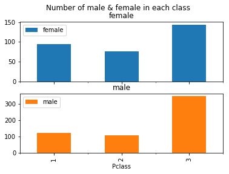

```python
distribution.unstack(level=0).plot(kind='bar', subplots=True, title='Number of male & female in each class')
```

### Exploring Data with histogram

[figure not shown]

```python
# Exploring Data with histogram

Gender =df.groupby(['Sex']).count()['Survived']

Gender.plot(kind='bar',title='Survived Pasengers classified by Gender');
```

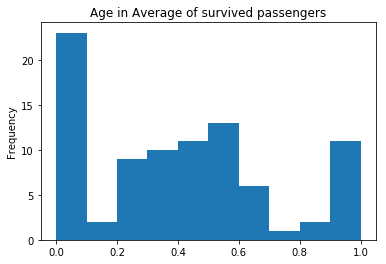

```python
# survived passengers

family =df.groupby(['Age']).mean()['Survived']



family.plot(kind='hist', title='Age in Average of survived passengers');
```

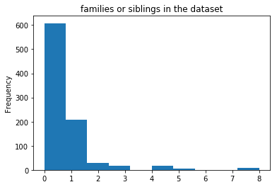

```python
# families or siblings in the dataset

family =df.groupby(['PassengerId']).mean()['SibSp']



family.plot(kind='hist', title='families or siblings in the dataset');
```